# DE_analysis_eels

Ludovic Dutoit 3/11/2020

First, I go through the dataset, here it is:

```r
library(tidyr)
library(DESeq2)
```

```r
library(pheatmap)
library(stringr)
library(ggplot2)
library(dplyr)
library(matrixStats)
library(pheatmap)
library(edgeR)
library("RColorBrewer")

counts=read.csv("results_files/RSEM_gene_counts.txt", sep="", head=T)
head(counts)
```

```
##                        silver_rep1 silver_rep2 silver_rep3 silver_rep4
## TRINITY_DN0_c0_g1             6861     6563.66     5170.09        6797
## TRINITY_DN100000_c0_g1           2        1.00        3.00           0
## TRINITY_DN100001_c0_g1           0        0.00        0.00           1
## TRINITY_DN100002_c0_g1           2        0.00        0.00           0
## TRINITY_DN100003_c0_g1           1        2.00        2.00           0
## TRINITY_DN100004_c0_g1           5        2.00        2.00           2
##                        silver_rep5 silver_rep6 yellow_rep1 yellow_rep2
## TRINITY_DN0_c0_g1          6089.59     6081.01     5431.87        2569
## TRINITY_DN100000_c0_g1        1.00        3.00        0.00           0
## TRINITY_DN100001_c0_g1        0.00        1.00        0.00           1
## TRINITY_DN100002_c0_g1        0.00        0.00        1.00           0
## TRINITY_DN100003_c0_g1        0.00        1.00        0.00           1
## TRINITY_DN100004_c0_g1        5.00        5.00        2.00           7
##                        yellow_rep3 yellow_rep4 yellow_rep5 yellow_rep6
## TRINITY_DN0_c0_g1             3088        3603        4274        5017
## TRINITY_DN100000_c0_g1           0           5           0           0
## TRINITY_DN100001_c0_g1           0           0           0           0
## TRINITY_DN100002_c0_g1           0           0           0           0
## TRINITY_DN100003_c0_g1           2           0           1           1
## TRINITY_DN100004_c0_g1           3           8           6          10
```

```r
colnames(counts)
```

```
##  [1] "silver_rep1" "silver_rep2" "silver_rep3" "silver_rep4" "silver_rep5"
##  [6] "silver_rep6" "yellow_rep1" "yellow_rep2" "yellow_rep3" "yellow_rep4"
## [11] "yellow_rep5" "yellow_rep6"
```

```r
######### Do the filtering
samples=cbind(colnames(counts),rep(c("silver","yellow"),each=6))
rownames(samples)<-samples[,1]
samples=as.data.frame(samples[,-1])
colnames(samples)<-"treatment"
treatment <- factor(rep(c("silver","yellow"),each=6))
```

### Basic filtering

```r
des <- model.matrix(~treatment)
dge <- DGEList(counts=counts)
keep <- filterByExpr(counts, des) # inside function of limma aware of the design to remove rad counts
dge <- dge[keep,keep.lib.sizes=FALSE]

dge<- calcNormFactors(dge)
print("After filtering, kept a matrix of X genes by Y samples:")
```

```
## [1] "After filtering, kept a matrix of X genes by Y samples:"
```

```r
dim(dge)
```

```
## [1] 32447    12
```

### Some visualisation after basic filtering

### Basic stats post filtering

How many reads per gene? This is the distribution in 5% quantiles of number of reads per sample per gene

```r
quantile(apply(dge$counts,1,sum)/12,seq(0,1,0.05))
```

```
##           0%           5%          10%          15%          20%          25%
## 6.583333e+00 1.241667e+01 1.548000e+01 1.916667e+01 2.375050e+01 2.991667e+01
##          30%          35%          40%          45%          50%          55%
## 3.785683e+01 4.850000e+01 6.283333e+01 8.266783e+01 1.103333e+02 1.489417e+02
##          60%          65%          70%          75%          80%          85%
## 2.071957e+02 2.924917e+02 4.198758e+02 6.036175e+02 8.733327e+02 1.250425e+03
##          90%          95%         100%
## 1.980895e+03 3.443662e+03 1.084269e+06
```

Up to 1e6 (maybe rRNA, to check). It means the most expressed genes has 1mio/reads per sample

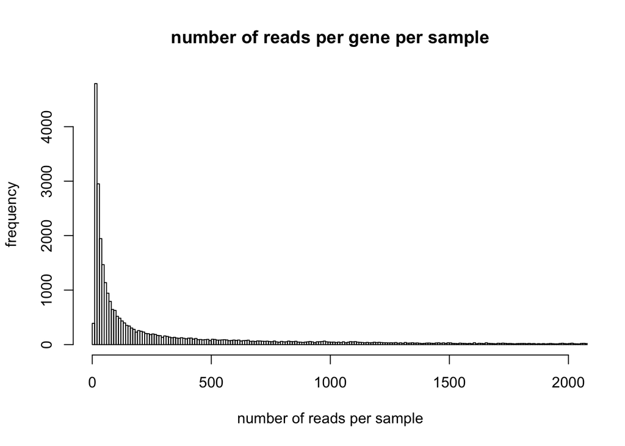

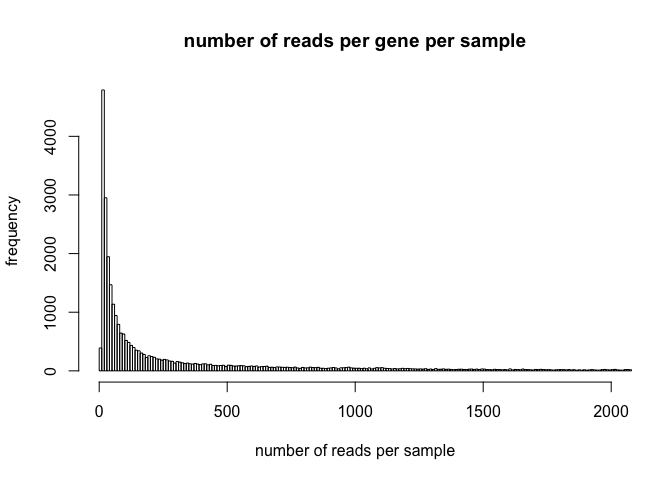

```r
hist(apply(dge$counts,1,sum)/12,xlim=c(0,2000),breaks=100000,main="number of reads per gene per sample",xlab= "number of reads per sample",ylab= "frequency") # 32447 genes passing filtering
```

What are the most expressed genes above 1000000 per sample:

```r
which(apply(dge$counts,1,sum)/12>1e6)
```

```
## TRINITY_DN2028_c0_g1 TRINITY_DN4587_c0_g1
##                10912                21449
```

TRINITY_DN2028_c0_g1 sequence matches Anguilla japonica eZPCa mRNA for egg envelope protein, complete cds:

```
>TRINITY_DN2028_c0_g1_i11 RANDOMLY PICKED ISOFORM
TACAGTAACCTCATGATCCATGCAGTCTGGCTACTGCATTGAAAGCTGCTTGGGGGGGGG…
```

TRINITY_DN4587 matches PREDICTED: Anguilla anguilla zona pellucida sperm-binding protein 4-like (LOC118223083), mRNA

```
>TRINITY_DN4587_c0_g1_i12 len=1019 path=[4:0-44 6:45-214 7:215-228 8:229-252 9:253-342 11:343-487 12:488-566 14:567-597 15:598-681 17:682-711 19:712-968 20:969-1018]
ACTTCACTGTGAAGCCTCTGGTCGGTGGCTGTAAGCTCCGTATTGGTCAGGACTACAGGC…
```

### DE analysis

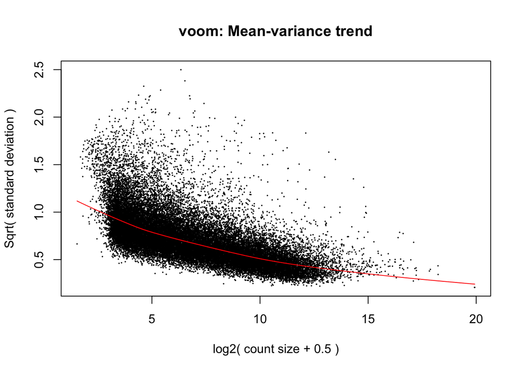

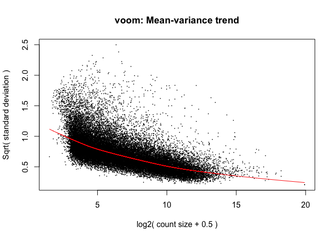

```r
logCPM <- cpm(dge, log=TRUE)
design <- model.matrix(~samples$treatment)

v <- voom(dge, design, plot=TRUE, normalize="quantile")
```

```r
pdf("MDS.pdf")
plotMDS(v, pch=19, col=rep(c("gray","gold"),each=6),cex=6,frame=F,main="",xlim=c(-2,4),cex.axis=3,xaxt="n",yaxt="n")
dev.off()
```

```r
fit <- lmFit(v, design)
fit <- eBayes(fit, trend=TRUE)
results<-topTable(fit, coef=ncol(design),n=Inf)

sum(results$adj.P.Val<0.05)
```

```
## [1] 10348
```

```r
##Table of DE genes

#DE_counts are the counts for the DE
DE_results<-results[results$adj.P.Val<0.05,] # DE_results are only the significant genes(p-value, log Fold-change,,,)

DE_counts<-dge[which(rownames(dge)%in%rownames(results)),]$counts #counts for significant genes


#positive means more in yellow
#negative means more in gray


##Overexpressed and underexpressed in general?
length(which(DE_results$logFC<(-1))) # how many genes under expressed in yellow  or more
```

```
## [1] 2851
```

```r
length(which(DE_results$logFC>1)) # how many genes over expressed in yellow
```

```
## [1] 2027
```

```r
##Overexpressed and underexpressed  by a actor 2 or more
length(which(DE_results$logFC<(-1))) # how many genes under expressed in yellow by a
```

```
## [1] 2851
```

```r
length(which(DE_results$logFC>1)) # how many genes over expressed in yellow
```

```
## [1] 2027
```

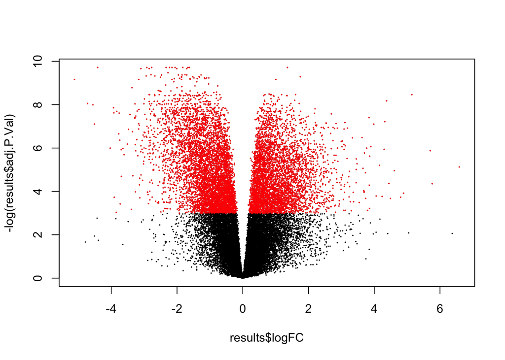

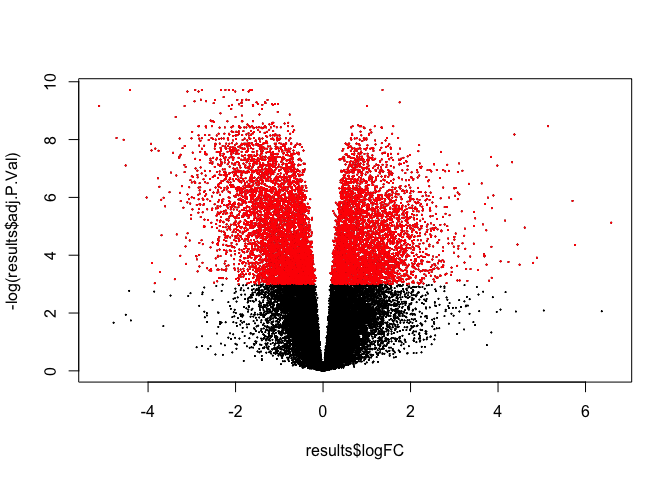

```r
###Volcano plot (relationship between Log Fold Change and -value)
plot(results$logFC,-log(results$adj.P.Val),pch=10,cex=0.1)
points(DE_results$logFC,-log(DE_results$adj.P.Val),pch=10,cex=0.1,col="red")
```

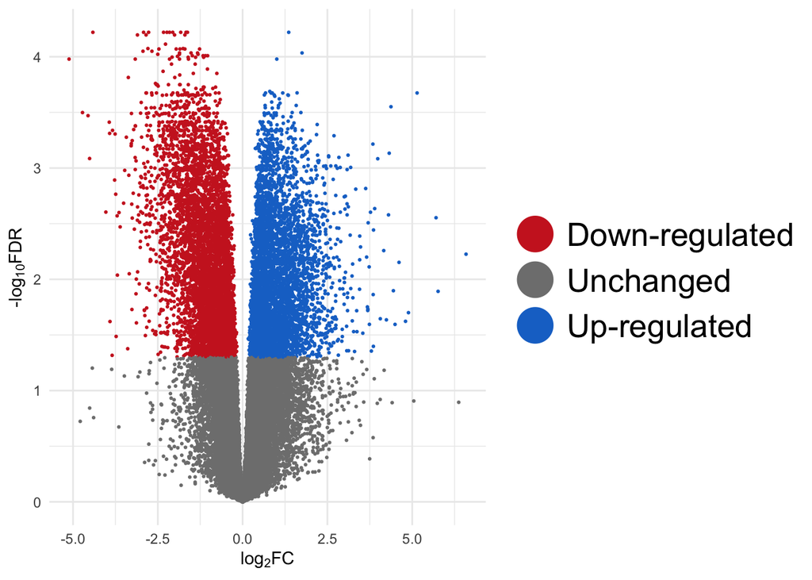

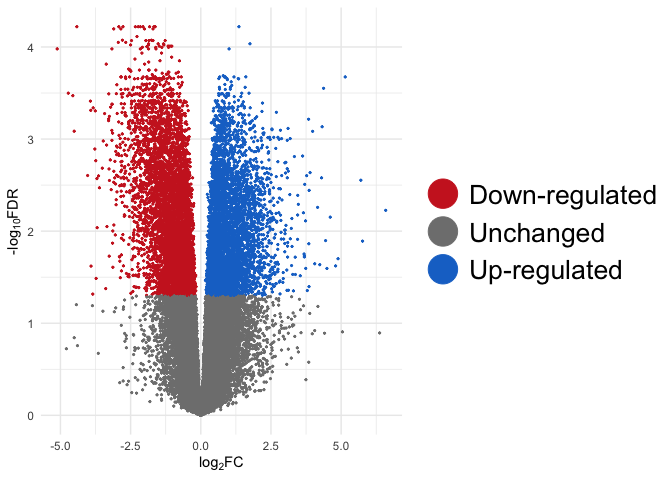

```r
results <- results %>%  mutate(
    Expression = case_when(logFC >= 0 & adj.P.Val <= 0.05 ~ "Up-regulated",
                           logFC <= 0 & adj.P.Val <= 0.05 ~ "Down-regulated",
                           TRUE ~ "Unchanged"))
  p2 <- ggplot(results, aes(logFC,-log10(adj.P.Val))) +
  geom_point(aes(color = Expression), size = 2/5) +
  xlab(expression("log"[2]*"FC")) +
  ylab(expression("-log"[10]*"FDR")) +
  scale_color_manual(values = c(  "firebrick3","gray50","dodgerblue3")) +
  guides(colour = guide_legend(override.aes = list(size=10),legend.key.size=10,title=""))  +theme_minimal()+theme(legend.text=element_text(size=20))

p2
```

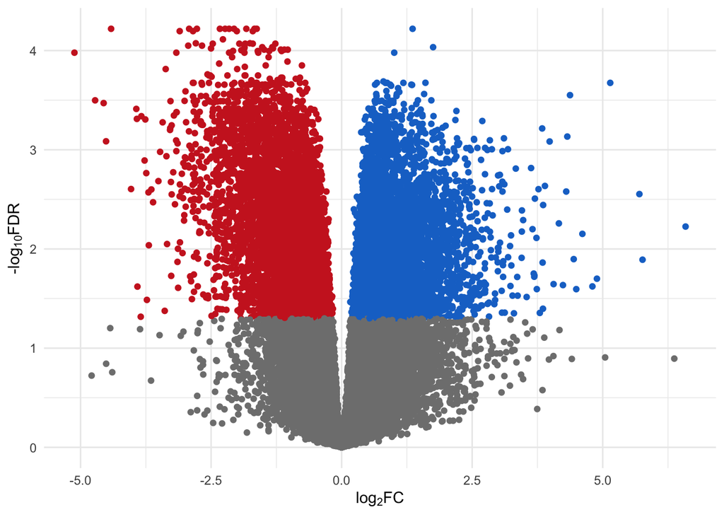

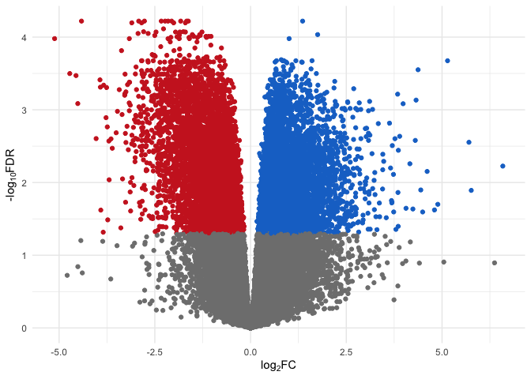

```r
ggsave( "ggvolcano.png", plot = p2)
results <- results %>%  mutate(
    Expression = case_when(logFC >= 0 & adj.P.Val <= 0.05 ~ "Up-regulated",
                           logFC <= 0 & adj.P.Val <= 0.05 ~ "Down-regulated",
                           TRUE ~ "Unchanged"))
  p2 <- ggplot(results, aes(logFC,-log10(adj.P.Val))) +
  geom_point(aes(color = Expression),show.legend=F) +
  xlab(expression("log"[2]*"FC")) +
  ylab(expression("-log"[10]*"FDR")) +
  scale_color_manual(values = c(  "firebrick3","gray50","dodgerblue3"))   +theme_minimal()

p2
```

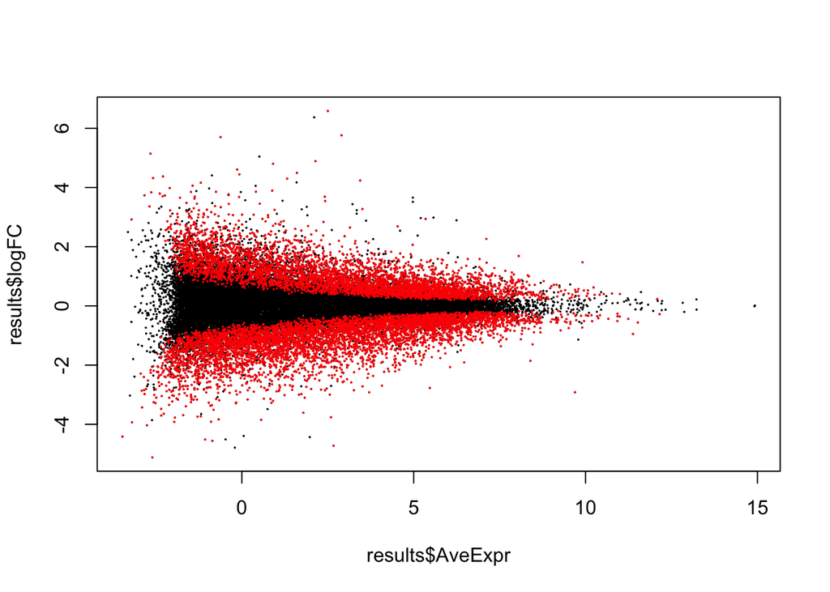

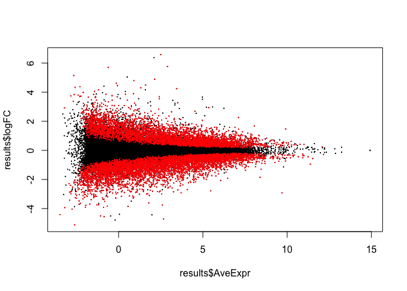

```r
ggsave( "ggvolcanonolegend.png", plot = p2)
plot(results$AveExpr,results$logFC,pch=10,cex=0.1)
points(DE_results$AveExpr,DE_results$logFC,pch=10,cex=0.1,col="red")
```

Let’s output those results as text tables that everyone can play with ( in excel or other). I saved it as DE_results.txt

```r
final_results_DE<-merge(DE_results,DE_counts,by=0)
colnames(final_results_DE)[1]<-"GeneID"
write.table(final_results_DE,"DE_results.txt",row.names=T,col.names=T,sep="\t")
```

# GO writing

```r
write(rownames(DE_results),"allDE.txt",sep="n")

write.table(rownames(DE_results)[which(DE_results$logFC>0)],"upregulated.txt",row.names=F,col.names=F,quote=F)
write.table(rownames(DE_results)[which(DE_results$logFC<0)],"downregulated.txt",row.names=F,col.names=F,quote=F)

write(rownames(dge$counts),"backgroundGO.txt",sep="\n")

write(rownames(dge$counts)[-which(rownames(dge$counts)%in%rownames(DE_results))],"backgroundGOnooverlap.txt",sep="n")
```

Split into logfoldchangeabove0 and logfoldchangebelow0

And finally we upload the results for ALL the genes:

```r
final_results<-merge(results,dge$counts,by=0)
colnames(final_results)[1]<-"GeneID"
write.table(final_results,"ALLgenes_results.txt",row.names=T,col.names=T,sep="\t")
```

### Saving data for plotting_genes.R

```r
###Careful, dirty fix
counts<-cpm(dge$counts)
save(counts,results,file="countsand_logFCforplottingGene.RData")
rm(counts) #to make sure I don't use it thinking it is counts
```

## Additional figures

Volcano plot with FC threshold at 2:

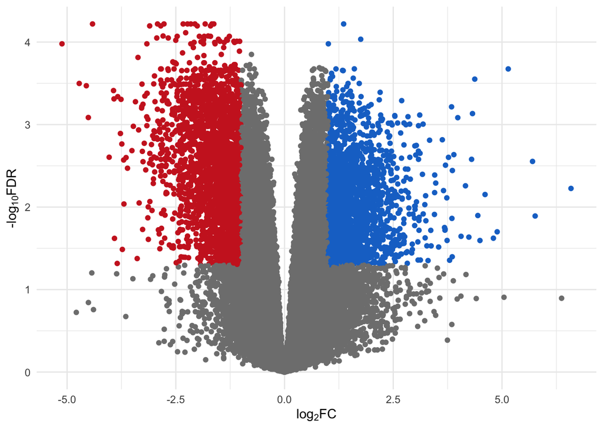

[figure not shown]

```r
results <- results %>%  mutate(
    Expression = case_when(logFC >= log2(2) & adj.P.Val <= 0.05 ~ "Up-regulated",
                           logFC <= -log2(2) & adj.P.Val <= 0.05 ~ "Down-regulated",
                           TRUE ~ "Unchanged"))
  p2 <- ggplot(results, aes(logFC,-log10(adj.P.Val))) +
  geom_point(aes(color = Expression),show.legend=F) +
  xlab(expression("log"[2]*"FC")) +
  ylab(expression("-log"[10]*"FDR")) +
  scale_color_manual(values = c(  "firebrick3","gray50","dodgerblue3"))   +theme_minimal() #+geom_vline(xintercept = c(-2,2),  color = "black", size=0.5)

  p2
```

```r
  ggsave("ggvolcanoFC2nolegend.pdf",plot = p2)
```

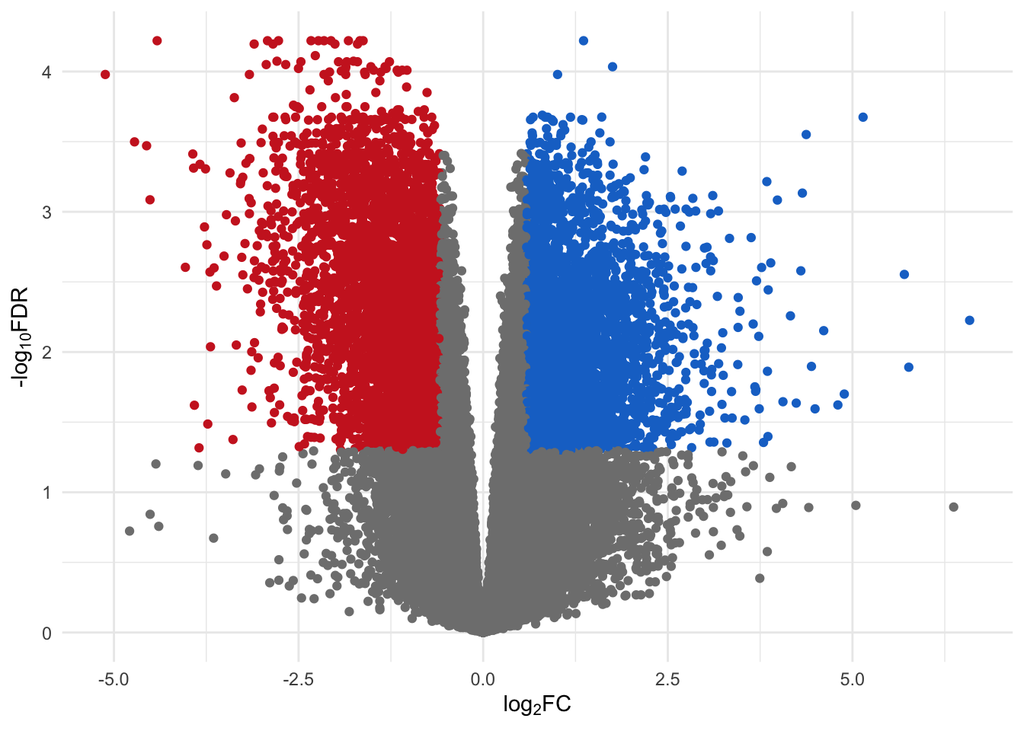

[figure not shown]

```r
results <- results %>%  mutate(
    Expression = case_when(logFC >= log2(1.5) & adj.P.Val <= 0.05 ~ "Up-regulated",
                           logFC <= -log2(1.5) & adj.P.Val <= 0.05 ~ "Down-regulated",
                           TRUE ~ "Unchanged"))
  p2 <- ggplot(results, aes(logFC,-log10(adj.P.Val))) +
  geom_point(aes(color = Expression),show.legend=F) +
  xlab(expression("log"[2]*"FC")) +
  ylab(expression("-log"[10]*"FDR")) +
  scale_color_manual(values = c(  "firebrick3","gray50","dodgerblue3"))   +theme_minimal() #+geom_vline(xintercept = c(-1.5,1.5),  color = "black", size=0.5)

  p2
```

```r
  ggsave("ggvolcanonFC15nolegend.pdf",plot = p2)
```

Sample clustering:

```r
 dds=DESeqDataSetFromMatrix(countData = round(dge$counts),colData = samples,design = ~rep(c("silver","yellow"),each=6))
    dds <- DESeq(dds)
```

```r
vsd<-vst(dds,blind=T)
sampleDists <- dist(t(assay(vsd)))
sampleDistMatrix <- as.matrix(sampleDists)
rownames(sampleDistMatrix) <- colnames(assay(vsd))
colnames(sampleDistMatrix) <- NULL
colors <- colorRampPalette( rev(brewer.pal(9, "Blues")) )(255)
pdf("clustering_heatmap.pdf")
pheatmap(sampleDistMatrix,
         clustering_distance_rows=sampleDists,
         clustering_distance_cols=sampleDists,
         col=colors)
dev.off()
```